# Bayesian Modelling

Joseph Li Wan Wang

2024-08-17

# Bayesian Modelling Project - Bayesian Hierarchical Model for Spotify Song Popularity

### *Joseph Li Wan Wang - Quantitative Data Science Methods: Psychometrics, Econometrics and Machine Learning*

## Introduction

What makes a song popular? There is an unmeasurable number of features that might affect how well a certain song will behave in the charts. Those variables interact with each other in such complex ways that artists usually claim that their success is mostly dependent on luck. This might be true, but as data scientists we ahould at least attempt to estimate and model the phenomenae that contribute to a song’s popularity, since the music industry is one of the most important ones in the field of entertainment.

In this project, our aim is to disentangle the effects of some song attributes on their popularity using Bayesian modeling. We will build and compare different models *(namely fully pooled, hierarchical, and fully unpooled)* to predict the popularity of a song based on its features and genre. Our focus will be on the hierarchical model approach, which allows us to model both the individual effects at the song level and the group-level effects at the genre level, leveraging the strengths of Bayesian inference to capture uncertainty and provide more robust estimates than more classic approaches that would provide simple linear estimates for each feature, which is an unlikely way of how the underlying data generating process might be producing our data.

## Data exploration and Pre-Processing

Firstly, we want to choose explore the dataset we will use to carry out our project. I found a publicly available dataset on kaggle that gathers the top 2000 tracks on Spotify from 1956 to 2019. This dataset has no missing values, is clean, well-organized and has a wide set of variables that we can work on. More information and access to the dataset in the link below:

https://www.kaggle.com/datasets/iamsumat/spotify-top-2000s-mega-dataset

We start the dataset exploration by visualizing how the data is distributed for each quantitative variable in histograms. Based on this visual assessment we can choose which variables to work on for this project.

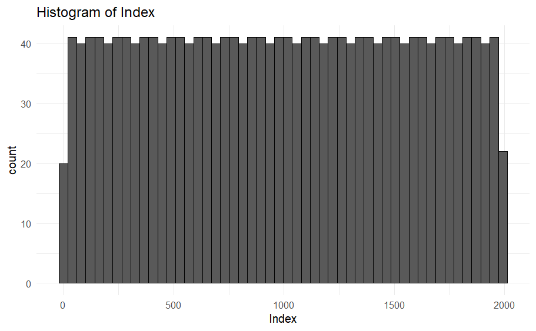

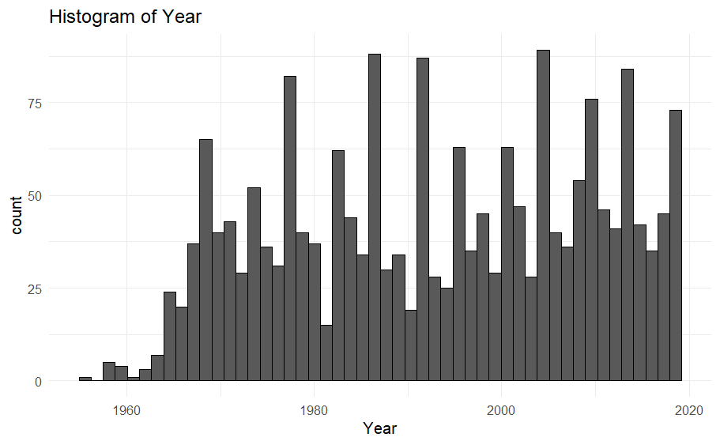

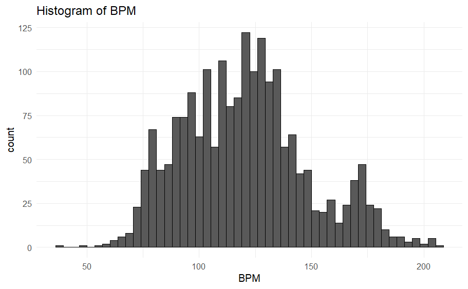

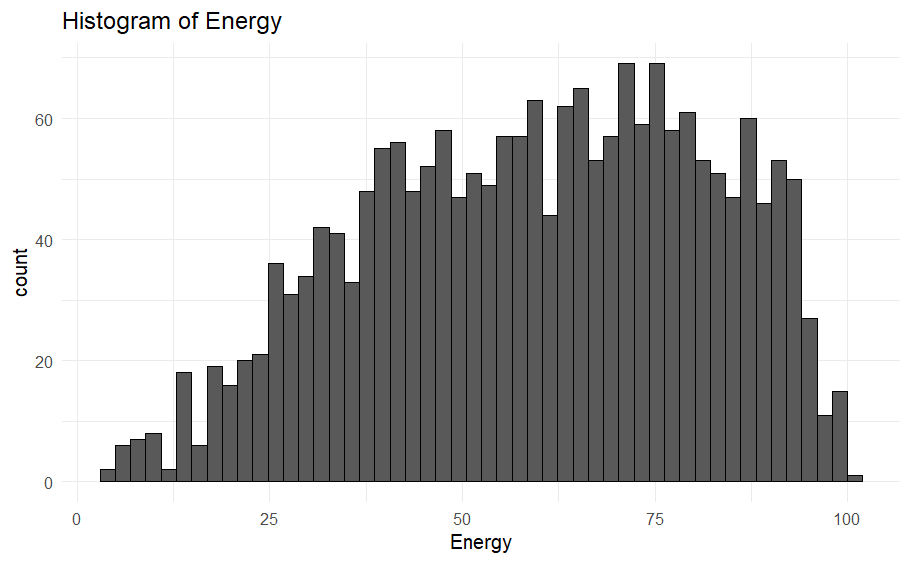

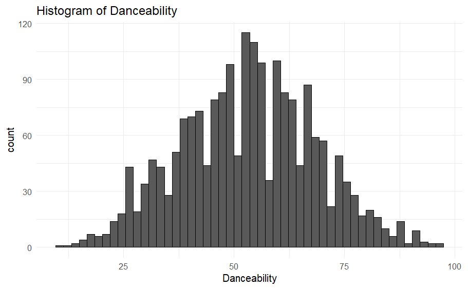

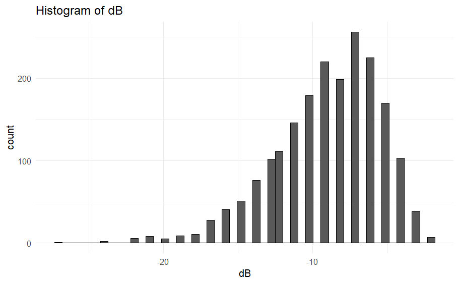

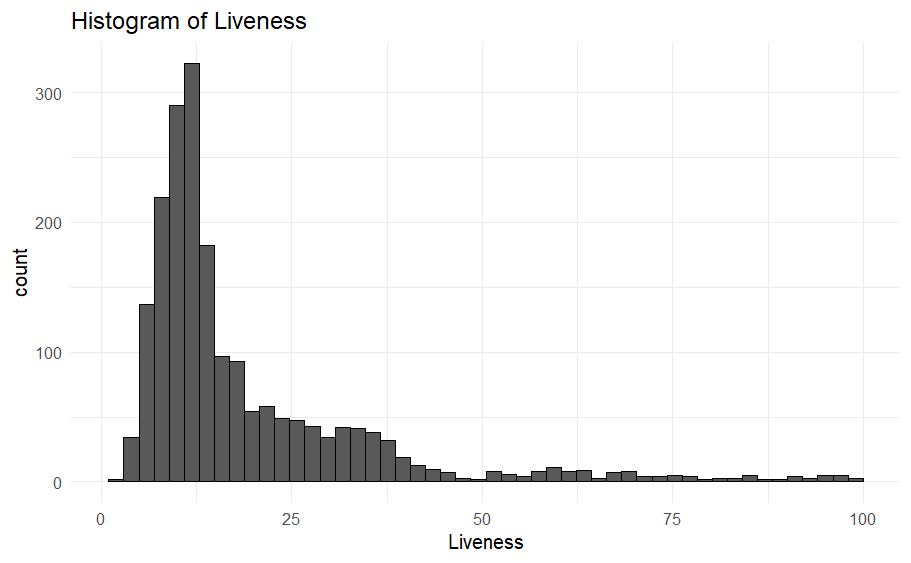

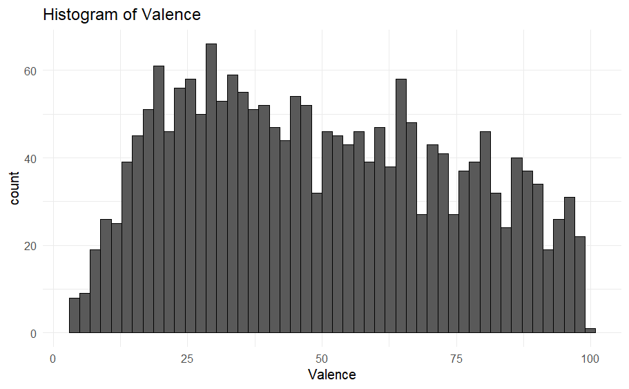

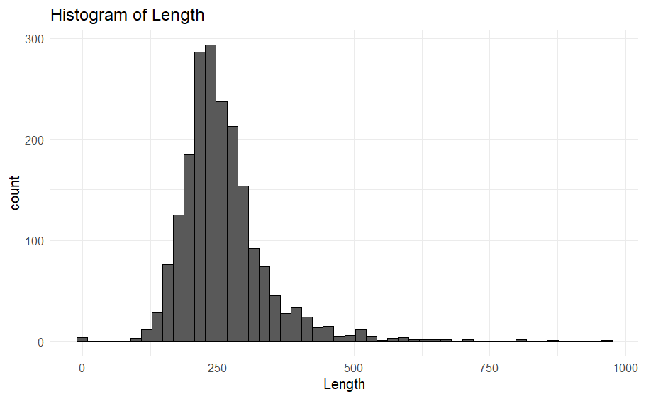

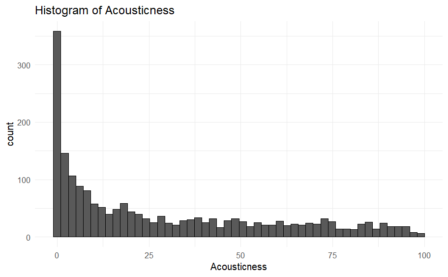

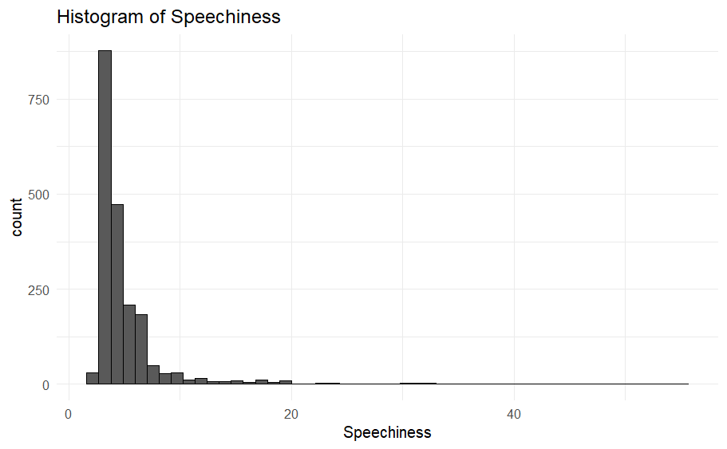

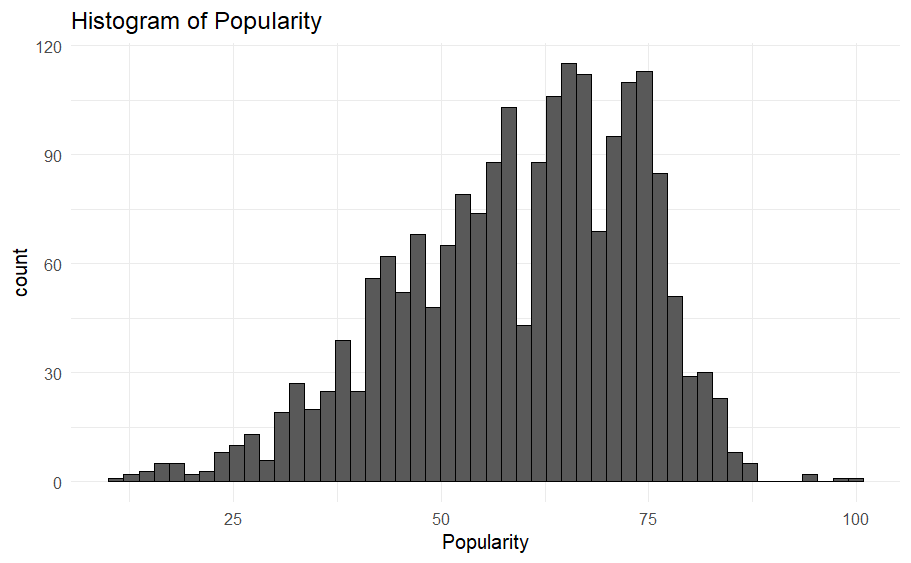

```r
library(ggplot2)
library(dplyr)
library(bayesplot)
# Load the dataset
data <- read.csv("C:\\Users\\Joseph\\Desktop\\Bayesian Modelling\\Assignment\\Spotify-2000.csv", header = TRUE, sep = ";")

# Filter for the numeric features
numeric_data <- data %>% select_if(is.numeric)

# Loop over each numeric variable to create a histogram
for (feature in names(numeric_data)) {
  # Generate a histogram for each numeric variable with 100 bins
  p <- ggplot(data = numeric_data, aes_string(x = feature)) +
    geom_histogram(bins = 50, color = "black") +
    labs(title = paste("Histogram of", feature),
         x = feature) +
    theme_minimal()

  # Print the plot
  print(p)
}
```

Out of simplicity purposes we will select for our analysis the best and most nicely normally distributed features for future analysis in our project: Popularity, Danceability and Length.

Next, we will plot the distribution of the popularity conditioned on each and every single genre to asses visually if they might be a genre dependent variable or not. My knowledge about music features does not suffice to know it exactly, so this is the best method of assessment i could think of.

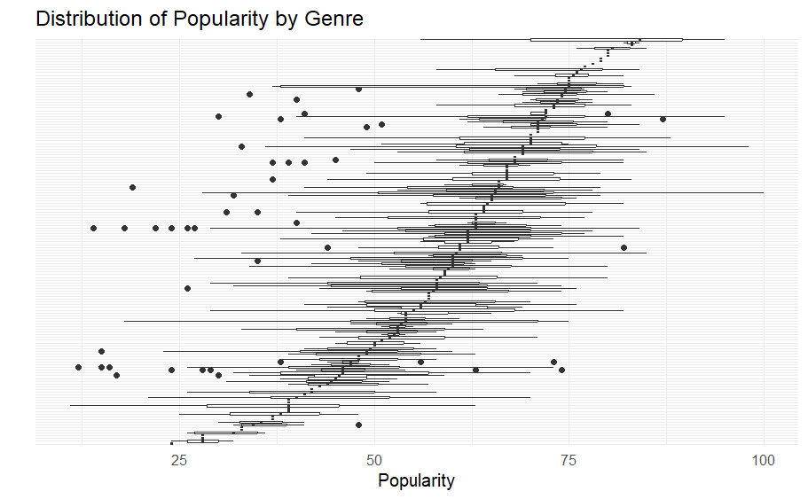

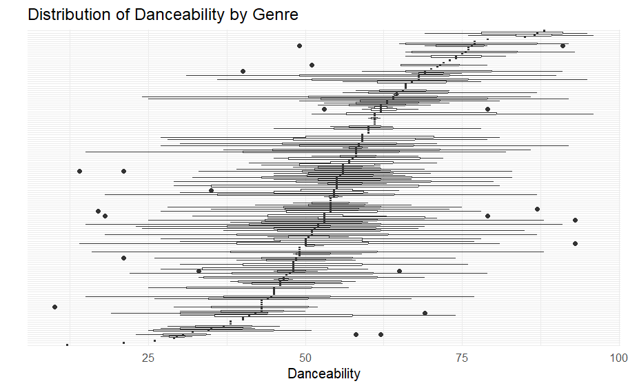

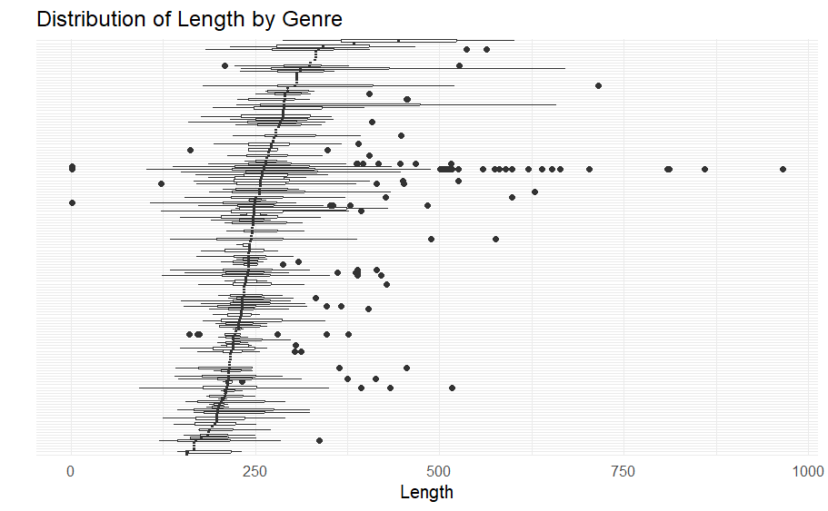

```r
# Define the list of features
features <- c("Popularity", "Danceability", "Length")

# Loop over each feature to create a plot
for (feature in features) {
  # Reorder genres (We use the median to account for outliers)
  data <- data %>%
    mutate(Genre = reorder(Genre, get(feature), FUN = median))

  # Generate a plot for each feature by genre
  p <- ggplot(data, aes_string(x = "Genre", y = feature)) +
    geom_boxplot() +
    coord_flip() +
    labs(title = paste("Distribution of", feature, "by Genre"),
         x = "",
         y = feature) +
    theme_minimal() +
    theme(axis.text.y = element_blank(), # Eliminate genre names because they are not readable
          axis.ticks.y = element_blank())

  # Print the plot
  print(p)
}
```

By having a rough look on the inter-quartile distance with respect to the means, we can see that there are some genres that have a significantly higher popularity than others. This is a good indicator that grouping by genre might be a good idea to model the popularity of a song. Something similar happens with the danceability feature, but not with the length of the song. Therefore, danceability should be included in the second level of our model (genre), while length should be in the first level (song).

In the next step we will adapt the “length” feature to be able to be used with the same priors as the other variables. For this purpose, we will delete the outliers and rescale to fit the 0 to 100 model like the other features.

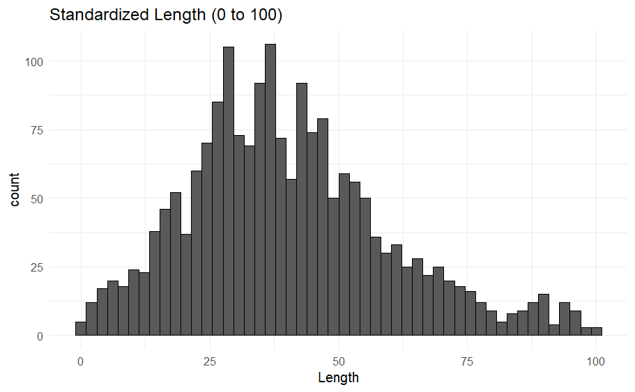

```r
# Define outliers
lower_bound <- quantile(data$Length, 0.01)
upper_bound <- quantile(data$Length, 0.96)

# Filter out the outliers
data <- data %>%
  filter(Length >= lower_bound & Length <= upper_bound)

# Standardize the Length variable to have a range from 0 to 100
data <- data %>%
  mutate(Length_standardized = (Length - min(Length)) / (max(Length) - min(Length)) * 100)

# Plot the standardized Length variable
ggplot(data, aes(x = Length_standardized)) +
  geom_histogram(bins = 50, color = "black") +
  labs(title = "Standardized Length (0 to 100)",
       x = "Length") +
  theme_minimal()
```

Now, the song length feature looks much better and normally distributed to use for our analeses.

Once the data has been explored and pre-processed, we can continue by designing the three models we want to compare.

## Model Setting

In the next step we will build the models we want to compare using weakly informative priors. This task will be made easier knowing that our variables are roughly normally distributed and range from 0 to 100.

### Fully Pooled Model

For this model we ignore any hierarchical genre dependency. Therefore, all individual songs are pooled together in a very simplified model.

Assuming all our variables are normally distributed the model would be the following:

$$\text{Popularity}_i \sim \mathcal{N}(\mu
+ \beta_{\text{Danceability}} \times \text{Danceability}_i +
\beta_{\text{Length}} \times \text{Length}_i, \sigma^2)$$

To run the model we will specify weakly informative priors:

$µ ∼ N (50, 20)$

$\beta_{Danceability} ∼ N(0,20)$

$\beta_{Length} ∼ N(0,20)$

$σ ∼ lognormal(1, 1)$

```r
if (!require("rjags")) install.packages("rjags")
```

```
Linked to JAGS 4.3.1
Loaded modules: basemod,bugs
```

```r
if (!require("coda")) install.packages("coda")
if (!require("ggplot2")) install.packages("ggplot2")

library(rjags)
library(coda)
library(ggplot2)

# Set seed for reproducibility
set.seed(123)

fpm_string <- "
model{
  # Likelihood
  for (i in 1:N) {
    Popularity[i] ~ dnorm(y[i], tau)
    y[i] <- mu + beta_danceability * Danceability[i] + beta_length * Length[i]
  }
  # Priors
  mu ~ dnorm(50, 0.0025)  # Prior for intercept (Around the mean)
  beta_danceability ~ dnorm(0, 0.0025)  # Danceability slope (No a-priori effect)
  beta_length ~ dnorm(0, 0.0025)  # Length slope (No a-priori effect)
  tau <- 1/(sigma * sigma)  # Precition
  sigma ~ dlnorm(1, 1)  # Variance
}
"
```

### Fully Unpooled (Heterogeneous) Model

In this case we ignore dependencies between genres and model each genre separately. This results in a overly complex model prone to overfitting because we allow for each genre to come from a different distribution (every genre has it’s own mean and sd: $Genre_{ij} \sim \mathcal{N}(\mu_j, \sigma_j)$):

$$\text{Popularity}_{ij} \sim
\mathcal{N}(\mu_j + \beta_{\text{Danceability}_j} \times
\text{Danceability}_{ij} + \beta_{\text{Length}_j} \times
\text{Length}_{ij}, \sigma_j^2)$$

Specifying the same priors as before:

```r
fum_string <- "
model {
  # Likelihood for every song
  for (i in 1:N) {
    Popularity[i] ~ dnorm(y[i], tau[i])
    y[i] <- genremu[genre[i]] + beta_danceability[genre[i]] * Danceability[i] + beta_length[genre[i]] * Length[i]
    tau[i] <- genretau[genre[i]]
  }

  # Priors
  for (j in 1:J) {
    genremu[j] ~ dnorm(50, 0.0025)  # Intercept
    beta_danceability[j] ~ dnorm(0, 0.0025)  # Danceability slope
    beta_length[j] ~ dnorm(0, 0.0025)  # Length slope
    genresigma[j] ~ dlnorm(1, 1)  # Variance
    genretau[j] <- 1 / (genresigma[j] * genresigma[j])
  }
}
"
```

### Hierarchical Model

This model lies in between the last two in terms of the complexity-generalizebility trade-off. It accounts for some differences among genres for our estimators, but also takes into consideration that genres are related and come from the same distribution which in our case is the music industry and the listeners.

The follows is as it follows:

$$\text{Popularity}_{ij} \sim \mathcal{N}\left(\mu_j +
\beta_{\text{Danceability}_j} \times \text{Danceability}_{ij} +
\beta_{\text{Length}_j} \times \text{Length}_{ij}, \sigma^2\right)$$

Where we can decompose the estimators such as:

$$\mu_j = \mu_{Genre}+\nu_{0j}$$
$$\beta_{\text{Danceability}_j} = \beta_{\text{Danceability}} + \nu_{1j}$$

$$\beta_{\text{Length}_j} = \beta_{\text{Length}} + \nu_{2j}$$

```r
bhm_string <- "
model{

  # likelihood (for every song)
  for (i in 1:N){
    Popularity[i] ~ dnorm(mu[i], tau)
    mu[i] <- genremu[genre[i]] + beta_danceability[genre[i]] * Danceability[i] + beta_length[genre[i]] * Length[i]
  }

  # priors
  for (j in 1:J){
    genremu[j] ~ dnorm(genremean, genretau)
    beta_danceability[j] ~ dnorm(mu_beta_danceability, tau_beta_danceability)
    beta_length[j] ~ dnorm(mu_beta_length, tau_beta_length)
  }

  sigma ~ dlnorm(1, 1)

  # hyper priors
  genremean ~ dnorm(50, 0.0025)
  genresigma ~ dlnorm(-1, 1)

  mu_beta_danceability ~ dnorm(0, 0.0025)
  sigma_beta_danceability ~ dlnorm(1, 1)

  mu_beta_length ~ dnorm(0, 0.0025)
  sigma_beta_length ~ dlnorm(1, 1)

  # Derived quantities:
  tau <- 1/(sigma * sigma)
  genretau <- 1/(genresigma * genresigma)
  tau_beta_danceability <- 1 / (sigma_beta_danceability * sigma_beta_danceability)
  tau_beta_length <- 1 / (sigma_beta_length * sigma_beta_length)

}
"
```

## Run the models

```r
# Prepare the data list for JAGS
jags_data <- list(
  Popularity = data$Popularity,
  Danceability = data$Danceability,
  Length = data$Length_standardized,
  genre = as.numeric(as.factor(data$Genre)),  # Convert genre to numeric
  J = length(unique(data$Genre)),
  N = nrow(data)
)
```

### Fully Pooled Model

```r
# Fully Pooled Model
fpm_model <- jags.model(textConnection(fpm_string), data = jags_data, n.chains = 3, n.adapt = 1000)
```

[output not shown]

```r
update(fpm_model, n.iter = 1000) # Burn-in
```

[output not shown]

```r
fpm_samples <- coda.samples(fpm_model, variable.names = c("mu", "beta_danceability", "beta_length", "sigma"), n.iter = 5000)
```

[output not shown]

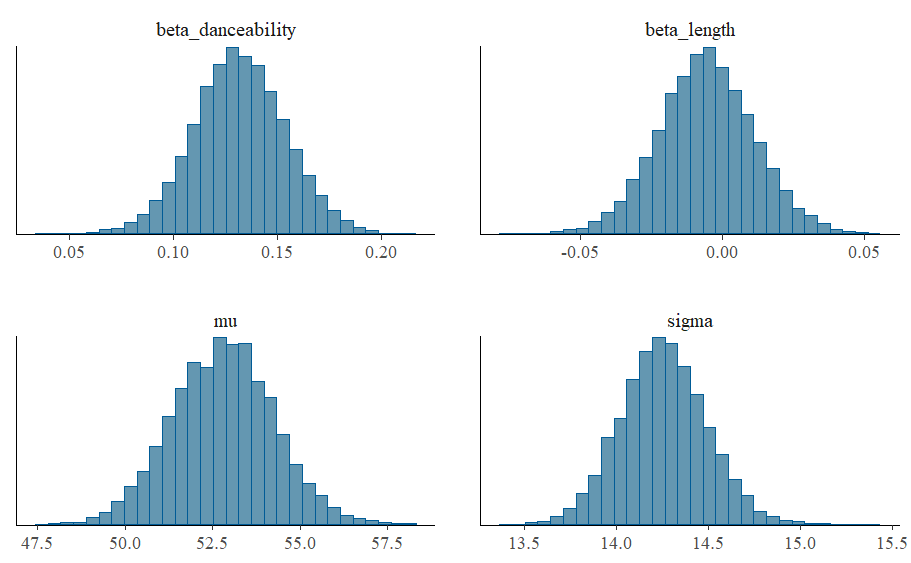

```r
# Prepare data to plot
fpm_samples_df <- as.matrix(fpm_samples)

# Plot the MCMC processes for each of our estimators
mcmc_hist(fpm_samples_df)
```

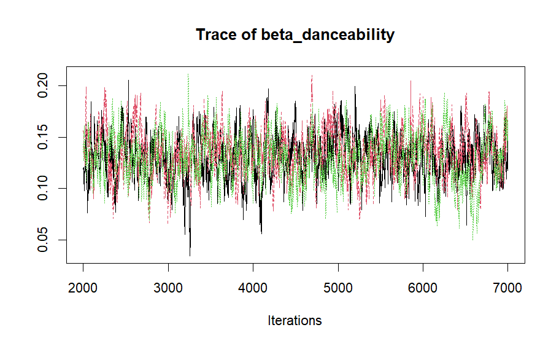

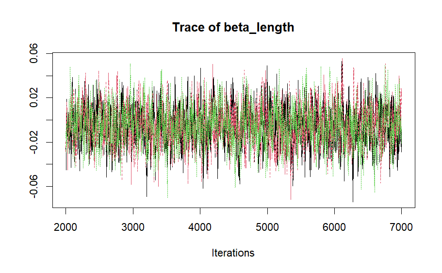

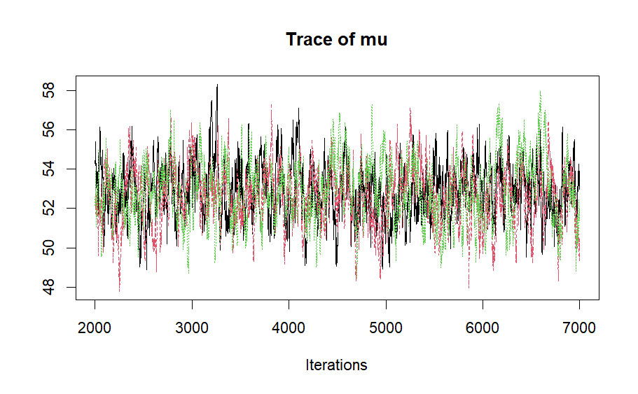

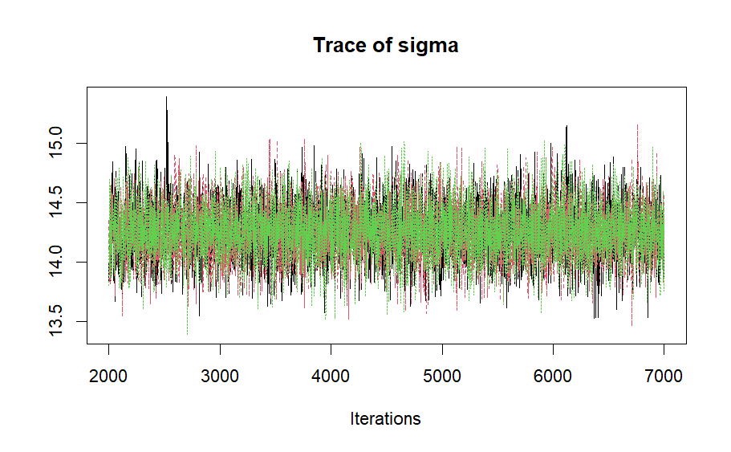

```r
traceplot(fpm_samples)
```

We can see that our parameters have converged around a certain range of values in all cases, and each of them is nicely distributed in a gaussian bell probably due to the pooling that allows us to use all of our sample. However this simplification implies loss of important information that could be used to interpret the data. In the next instances we will see more nuanced models.

### Fully Unpooled Model

```r
# Fully Unpooled Model
fum_model <- jags.model(textConnection(fum_string), data = jags_data, n.chains = 3, n.adapt = 1000)
```

[output not shown]

```r
update(fum_model, n.iter = 1000)
```

[output not shown]

```r
fum_samples <- coda.samples(fum_model, variable.names = c("genremu","beta_danceability", "beta_length", "genresigma", "genretau"), n.iter = 5000)
```

[output not shown]